# 6372 Project 1 - Life Expectancy

## Cross validating the models on the test data

```r
testASEfwd<-c()
testASEbwd<-c()
testASEstp<-c()

for (i in 1:18){
  # predicting the forward model on test set
  predictionsfwd<-predict.regsubsets(object=reg.fwd,newdata=test,id=i)
  testASEfwd[i]<-mean((test$life_expectancy-predictionsfwd)^2)

  # predicting the backward model on test set
  predictionsbwd<-predict.regsubsets(object=reg.bwd,newdata=test,id=i)
  testASEbwd[i]<-mean((test$life_expectancy-predictionsbwd)^2)

  # predicting stepwise model on test set
  predictionsstp<-predict.regsubsets(object=reg.stp,newdata=test,id=i)
  testASEstp[i]<-mean((test$life_expectancy-predictionsstp)^2)

}
```

## Plots for ASE

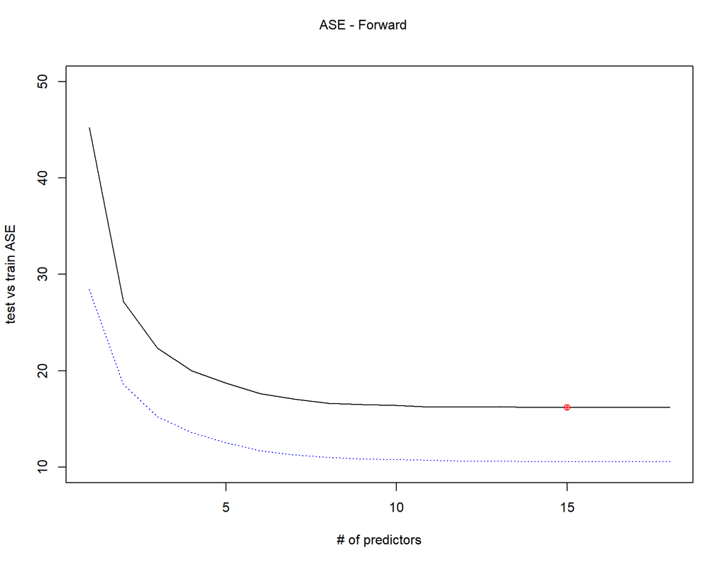

```r
par(mfrow=c(1,1))
plot(1:18,testASEfwd,type="l",xlab="# of predictors",ylab="test vs train ASE",ylim=c(10,50))
index<-which(testASEfwd==min(testASEfwd))
points(index,testASEfwd[index],col="red",pch=10)
rss<-summary(reg.fwd)$rss
lines(1:18,rss/2928,lty=3,col="blue")  #Dividing by 2928 since ASE=RSS/sample size
mtext("ASE - Forward", side = 3, line = -2, outer = TRUE)
```

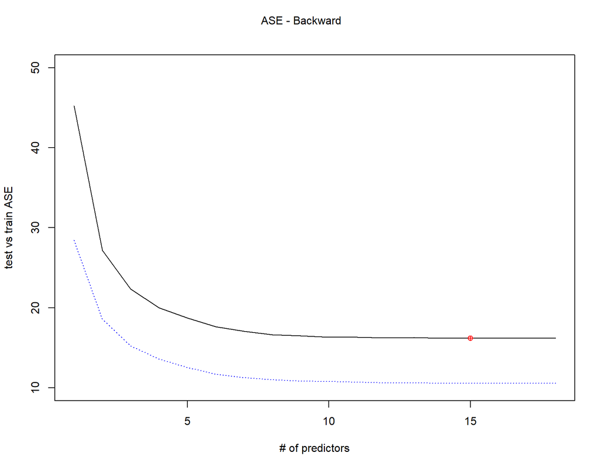

```r
par(mfrow=c(1,1))
plot(1:18,testASEbwd,type="l",xlab="# of predictors",ylab="test vs train ASE",ylim=c(10,50))
index<-which(testASEbwd==min(testASEbwd))
points(index,testASEbwd[index],col="red",pch=10)
rss<-summary(reg.bwd)$rss
lines(1:18,rss/2928,lty=3,col="blue")  #Dividing by 2928 since ASE=RSS/sample size
mtext("ASE - Backward", side = 3, line = -2, outer = TRUE)
```

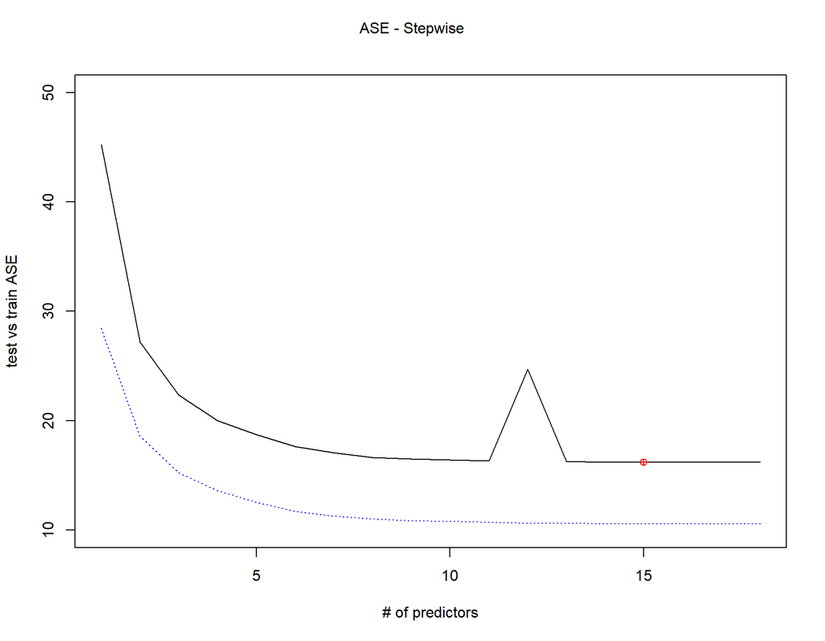

```r
par(mfrow=c(1,1))
plot(1:18,testASEstp,type="l",xlab="# of predictors",ylab="test vs train ASE",ylim=c(10,50))
index<-which(testASEstp==min(testASEstp))
points(index,testASEstp[index],col="red",pch=10)
rss3<-summary(reg.stp)$rss3
lines(1:18,rss/2928,lty=3,col="blue")  #Dividing by 2928 since ASE=RSS/sample size
mtext("ASE - Stepwise", side = 3, line = -2, outer = TRUE)
```

## Using forward backward, and stepwise to select max number of variables

```r
# the forward and backward models are exactly the same, we will proceed in analyzing only the bakward model


# final variable selection for backward variable selection - the forward and backwards method selected the same model in this case
reg.finalbwd=regsubsets(life_expectancy~. ,data=Life,method="backward",nvmax=12)
coef(reg.finalbwd,10)
```

```
##                     (Intercept)                statusDeveloping
##                    5.502614e+01                   -1.049242e+00
##                 adult_mortality          percentage_expenditure
##                   -2.054205e-02                    3.201944e-04
##                         measles                           polio
##                   -3.469699e-05                    3.131628e-02
##                      diphtheria                        hiv_aids
##                    4.042362e-02                   -4.856260e-01
##            thinness_10_19_years income_composition_of_resources
##                   -1.458279e-01                    6.818905e+00
##                       schooling
##                    8.002560e-01
```

```r
final.modelbwd <- lm(life_expectancy ~ status + adult_mortality + percentage_expenditure + measles + polio + diphtheria + hiv_aids + thinness_10_19_years + income_composition_of_resources + schooling + status:percentage_expenditure + I(hiv_aids^2) + I(sqrt(percentage_expenditure)), data=Life)

summary(final.modelbwd)
```

```
##
## Call:
## lm(formula = life_expectancy ~ status + adult_mortality + percentage_expenditure +
##     measles + polio + diphtheria + hiv_aids + thinness_10_19_years +
##     income_composition_of_resources + schooling + status:percentage_expenditure +
##     I(hiv_aids^2) + I(sqrt(percentage_expenditure)), data = Life)
##
## Residuals:
##      Min       1Q   Median       3Q      Max
## -21.5297  -2.1364  -0.0472   2.2408  15.7545
##
## Coefficients:
##                                           Estimate Std. Error t value Pr(>|t|)
## (Intercept)                              5.711e+01  6.022e-01  94.834  < 2e-16
## statusDeveloping                        -1.646e+00  2.775e-01  -5.933 3.32e-09
## adult_mortality                         -1.642e-02  7.932e-04 -20.702  < 2e-16
## percentage_expenditure                  -2.620e-04  9.880e-05  -2.652 0.008035
## measles                                 -2.771e-05  6.558e-06  -4.225 2.46e-05
## polio                                    2.648e-02  4.306e-03   6.149 8.84e-10
## diphtheria                               3.461e-02  4.280e-03   8.087 8.91e-16
## hiv_aids                                -1.164e+00  4.134e-02 -28.164  < 2e-16
## thinness_10_19_years                    -1.281e-01  1.951e-02  -6.565 6.16e-11
## income_composition_of_resources          5.871e+00  6.123e-01   9.590  < 2e-16
## schooling                                7.279e-01  4.071e-02  17.881  < 2e-16
## I(hiv_aids^2)                            1.974e-02  1.110e-03  17.791  < 2e-16
## I(sqrt(percentage_expenditure))          5.588e-02  1.022e-02   5.468 4.94e-08
## statusDeveloping:percentage_expenditure  4.458e-04  1.236e-04   3.606 0.000317
##
## (Intercept)                             ***
## statusDeveloping                        ***
## adult_mortality                         ***
## percentage_expenditure                  **
## measles                                 ***
## polio                                   ***
## diphtheria                              ***
## hiv_aids                                ***
## thinness_10_19_years                    ***
## income_composition_of_resources         ***
## schooling                               ***
## I(hiv_aids^2)                           ***
## I(sqrt(percentage_expenditure))         ***
## statusDeveloping:percentage_expenditure ***
## ---
## Signif. codes:  0 '***' 0.001 '**' 0.01 '*' 0.05 '.' 0.1 ' ' 1
##
## Residual standard error: 3.935 on 2914 degrees of freedom
## Multiple R-squared:   0.83,  Adjusted R-squared:  0.8293
## F-statistic:  1095 on 13 and 2914 DF,  p-value: < 2.2e-16
```

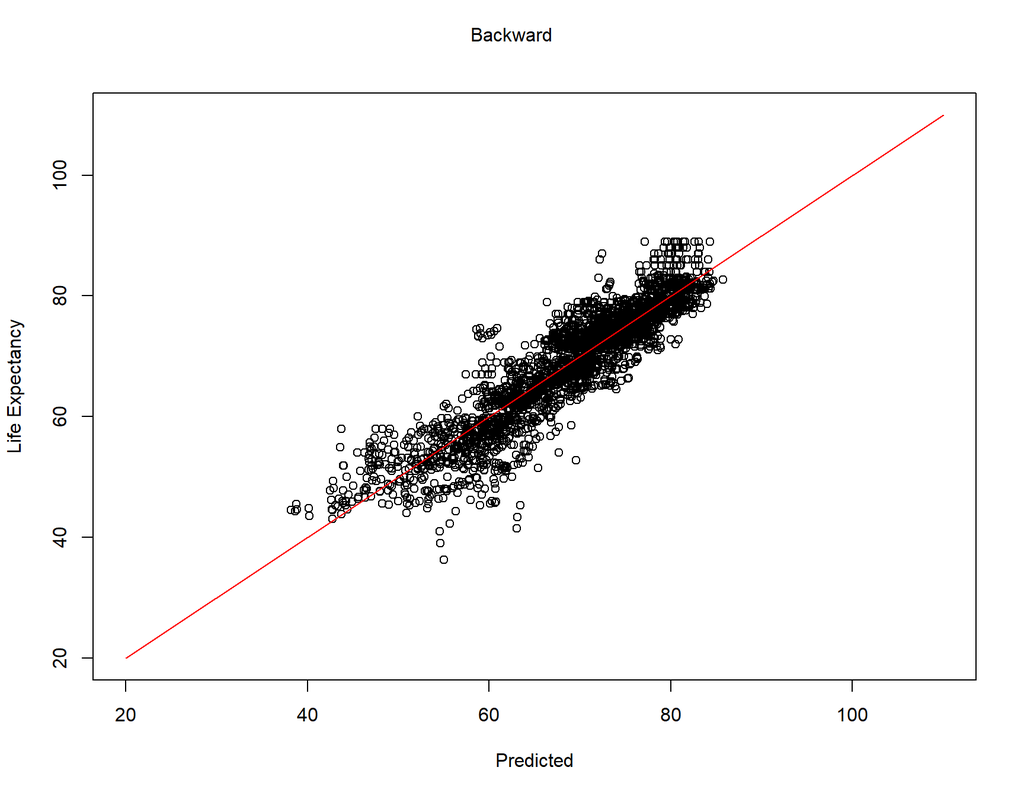

```r
plot(final.modelbwd$fitted.values,Life$life_expectancy,xlab="Predicted",ylab="Life Expectancy",xlim=c(20,110),ylim=c(20,110))
lines(c(20,110),c(20,110),col="red")
mtext("Backward", side = 3, line = -2, outer = TRUE)
```

```r
# final variable selection for stepwise variable selection
reg.finalstp=regsubsets(life_expectancy~.,data=Life,method="seqrep",nvmax=13)
coef(reg.finalstp,10)
```

```
##                     (Intercept)                statusDeveloping
##                    5.502614e+01                   -1.049242e+00
##                 adult_mortality          percentage_expenditure
##                   -2.054205e-02                    3.201944e-04
##                         measles                           polio
##                   -3.469699e-05                    3.131628e-02
##                      diphtheria                        hiv_aids
##                    4.042362e-02                   -4.856260e-01
##            thinness_10_19_years income_composition_of_resources
##                   -1.458279e-01                    6.818905e+00
##                       schooling
##                    8.002560e-01
```

```r
final.modelstp <- lm(life_expectancy ~ status + adult_mortality + percentage_expenditure + measles + polio + total_expenditure + diphtheria + hiv_aids + thinness_10_19_years + income_composition_of_resources + schooling + status:percentage_expenditure + I(hiv_aids^2) + I(sqrt(percentage_expenditure)), data=Life)

summary(final.modelstp)
```

```
##
## Call:
## lm(formula = life_expectancy ~ status + adult_mortality + percentage_expenditure +
##     measles + polio + total_expenditure + diphtheria + hiv_aids +
##     thinness_10_19_years + income_composition_of_resources +
##     schooling + status:percentage_expenditure + I(hiv_aids^2) +
##     I(sqrt(percentage_expenditure)), data = Life)
##
## Residuals:
##      Min       1Q   Median       3Q      Max
## -21.8882  -2.0941  -0.0528   2.2143  15.7951
##
## Coefficients:
##                                           Estimate Std. Error t value Pr(>|t|)
## (Intercept)                              5.678e+01  6.321e-01  89.836  < 2e-16
## statusDeveloping                        -1.574e+00  2.807e-01  -5.606 2.27e-08
## adult_mortality                         -1.640e-02  7.931e-04 -20.677  < 2e-16
## percentage_expenditure                  -2.705e-04  9.890e-05  -2.735 0.006268
## measles                                 -2.727e-05  6.562e-06  -4.155 3.34e-05
## polio                                    2.639e-02  4.305e-03   6.130 9.99e-10
## total_expenditure                        5.389e-02  3.228e-02   1.670 0.095119
## diphtheria                               3.427e-02  4.284e-03   8.001 1.77e-15
## hiv_aids                                -1.168e+00  4.140e-02 -28.222  < 2e-16
## thinness_10_19_years                    -1.233e-01  1.971e-02  -6.252 4.65e-10
## income_composition_of_resources          5.965e+00  6.147e-01   9.705  < 2e-16
## schooling                                7.188e-01  4.106e-02  17.507  < 2e-16
## I(hiv_aids^2)                            1.979e-02  1.110e-03  17.835  < 2e-16
## I(sqrt(percentage_expenditure))          5.676e-02  1.023e-02   5.548 3.15e-08
## statusDeveloping:percentage_expenditure  4.419e-04  1.236e-04   3.575 0.000356
##
## (Intercept)                             ***
## statusDeveloping                        ***
## adult_mortality                         ***
## percentage_expenditure                  **
## measles                                 ***
## polio                                   ***
## total_expenditure                       .
## diphtheria                              ***
## hiv_aids                                ***
## thinness_10_19_years                    ***
## income_composition_of_resources         ***
## schooling                               ***
## I(hiv_aids^2)                           ***
## I(sqrt(percentage_expenditure))         ***
## statusDeveloping:percentage_expenditure ***
## ---
## Signif. codes:  0 '***' 0.001 '**' 0.01 '*' 0.05 '.' 0.1 ' ' 1
##
## Residual standard error: 3.934 on 2913 degrees of freedom
## Multiple R-squared:  0.8302, Adjusted R-squared:  0.8294
## F-statistic:  1017 on 14 and 2913 DF,  p-value: < 2.2e-16
```

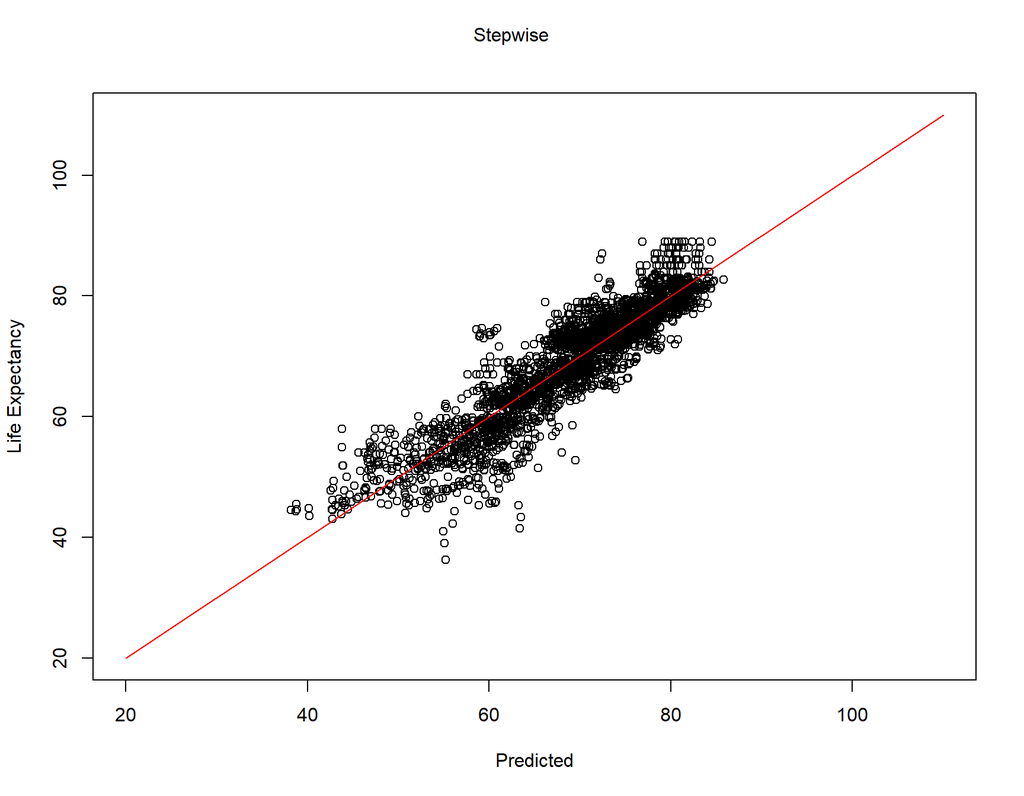

```r
plot(final.modelstp$fitted.values,Life$life_expectancy,xlab="Predicted",ylab="Life Expectancy",xlim=c(20,110),ylim=c(20,110) )
lines(c(20,110),c(20,110),col="red")
mtext("Stepwise", side = 3, line = -2, outer = TRUE)
```

```r
# final variable selection for lasso variable selection
final.modellso <- reg.lso

summary(final.modellso)
```

```
##
## Call:
## lm(formula = life_expectancy ~ adult_mortality + measles + polio +
##     diphtheria + hiv_aids + thinness_10_19_years + income_composition_of_resources +
##     schooling + I(sqrt(percentage_expenditure)), data = Life)
##
## Residuals:
##      Min       1Q   Median       3Q      Max
## -22.0137  -2.1757  -0.0672   2.3400  17.1769
##
## Coefficients:
##                                   Estimate Std. Error t value Pr(>|t|)
## (Intercept)                      5.370e+01  5.072e-01 105.882  < 2e-16 ***
## adult_mortality                 -2.033e-02  8.103e-04 -25.085  < 2e-16 ***
## measles                         -3.312e-05  6.931e-06  -4.779 1.85e-06 ***
## polio                            3.120e-02  4.548e-03   6.860 8.35e-12 ***
## diphtheria                       4.005e-02  4.518e-03   8.864  < 2e-16 ***
## hiv_aids                        -4.901e-01  1.787e-02 -27.418  < 2e-16 ***
## thinness_10_19_years            -1.502e-01  2.044e-02  -7.346 2.64e-13 ***
## income_composition_of_resources  6.846e+00  6.421e-01  10.662  < 2e-16 ***
## schooling                        7.991e-01  4.223e-02  18.920  < 2e-16 ***
## I(sqrt(percentage_expenditure))  4.465e-02  4.064e-03  10.986  < 2e-16 ***
## ---
## Signif. codes:  0 '***' 0.001 '**' 0.01 '*' 0.05 '.' 0.1 ' ' 1
##
## Residual standard error: 4.166 on 2918 degrees of freedom
## Multiple R-squared:  0.8093, Adjusted R-squared:  0.8087
## F-statistic:  1376 on 9 and 2918 DF,  p-value: < 2.2e-16
```

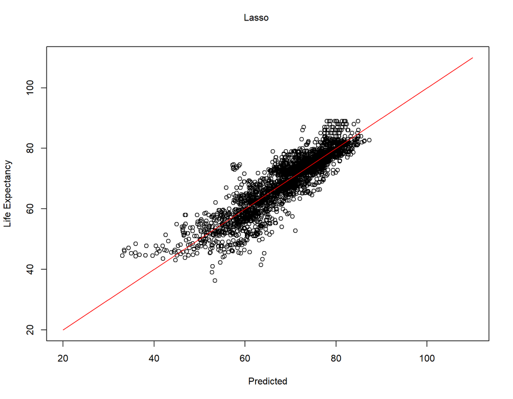

```r
plot(final.modellso$fitted.values,Life$life_expectancy,xlab="Predicted",ylab="Life Expectancy",xlim=c(20,110),ylim=c(20,110))
lines(c(20,110),c(20,110),col="red")
mtext("Lasso", side = 3, line = -2, outer = TRUE)
```

## ANOVA lack of fit test between final predictive model and interpretable model

```r
anova(final.modelbwd, final.modellso)
```

|  | Res.Df | RSS | Df | Sum of Sq | F | Pr(>F) |
| --- | --- | --- | --- | --- | --- | --- |
| 1 | 2914 | 45125.80 | NA | NA | NA | NA |
| 2 | 2918 | 50636.69 | -4 | -5510.888 | 88.96644 | 1.968425e-71 |

H0: Backward Model Fit = Lasso Model Fit  
Ha: Backward Model Fit != Lasso Model Fit

There is sufficient evidence to suggest that these models do not fit the data the same.

Reject H0

p-value: < 2.2e-16

## ANOVA lack of fit test between stepwise and backward model

```r
anova(final.modelstp, final.modelbwd)
```

|  | Res.Df | RSS | Df | Sum of Sq | F | Pr(>F) |
| --- | --- | --- | --- | --- | --- | --- |
| 1 | 2913 | 45082.67 | NA | NA | NA | NA |
| 2 | 2914 | 45125.80 | -1 | -43.13789 | 2.787339 | 0.09511933 |

H0: Stepwise Model Fit = Backward Model Fit  
Ha: Stepwise Model Fit != Backward Model Fit

There is not enough evidence to suggest that these models fit the data differently.

Fail to reject H0

p-value: 0.095

## Using forward backward, and stepwise to select max number of variables

```r
# final predictive model
final.predictive <- final.modelstp


summary(final.predictive)
```

```
##
## Call:
## lm(formula = life_expectancy ~ status + adult_mortality + percentage_expenditure +
##     measles + polio + total_expenditure + diphtheria + hiv_aids +
##     thinness_10_19_years + income_composition_of_resources +
##     schooling + status:percentage_expenditure + I(hiv_aids^2) +
##     I(sqrt(percentage_expenditure)), data = Life)
##
## Residuals:
##      Min       1Q   Median       3Q      Max
## -21.8882  -2.0941  -0.0528   2.2143  15.7951
##
## Coefficients:
##                                           Estimate Std. Error t value Pr(>|t|)
## (Intercept)                              5.678e+01  6.321e-01  89.836  < 2e-16
## statusDeveloping                        -1.574e+00  2.807e-01  -5.606 2.27e-08
## adult_mortality                         -1.640e-02  7.931e-04 -20.677  < 2e-16
## percentage_expenditure                  -2.705e-04  9.890e-05  -2.735 0.006268
## measles                                 -2.727e-05  6.562e-06  -4.155 3.34e-05
## polio                                    2.639e-02  4.305e-03   6.130 9.99e-10
## total_expenditure                        5.389e-02  3.228e-02   1.670 0.095119
## diphtheria                               3.427e-02  4.284e-03   8.001 1.77e-15
## hiv_aids                                -1.168e+00  4.140e-02 -28.222  < 2e-16
## thinness_10_19_years                    -1.233e-01  1.971e-02  -6.252 4.65e-10
## income_composition_of_resources          5.965e+00  6.147e-01   9.705  < 2e-16
## schooling                                7.188e-01  4.106e-02  17.507  < 2e-16
## I(hiv_aids^2)                            1.979e-02  1.110e-03  17.835  < 2e-16
## I(sqrt(percentage_expenditure))          5.676e-02  1.023e-02   5.548 3.15e-08
## statusDeveloping:percentage_expenditure  4.419e-04  1.236e-04   3.575 0.000356
##
## (Intercept)                             ***
## statusDeveloping                        ***
## adult_mortality                         ***
## percentage_expenditure                  **
## measles                                 ***
## polio                                   ***
## total_expenditure                       .
## diphtheria                              ***
## hiv_aids                                ***
## thinness_10_19_years                    ***
## income_composition_of_resources         ***
## schooling                               ***
## I(hiv_aids^2)                           ***
## I(sqrt(percentage_expenditure))         ***
## statusDeveloping:percentage_expenditure ***
## ---
## Signif. codes:  0 '***' 0.001 '**' 0.01 '*' 0.05 '.' 0.1 ' ' 1
##
## Residual standard error: 3.934 on 2913 degrees of freedom
## Multiple R-squared:  0.8302, Adjusted R-squared:  0.8294
## F-statistic:  1017 on 14 and 2913 DF,  p-value: < 2.2e-16
```

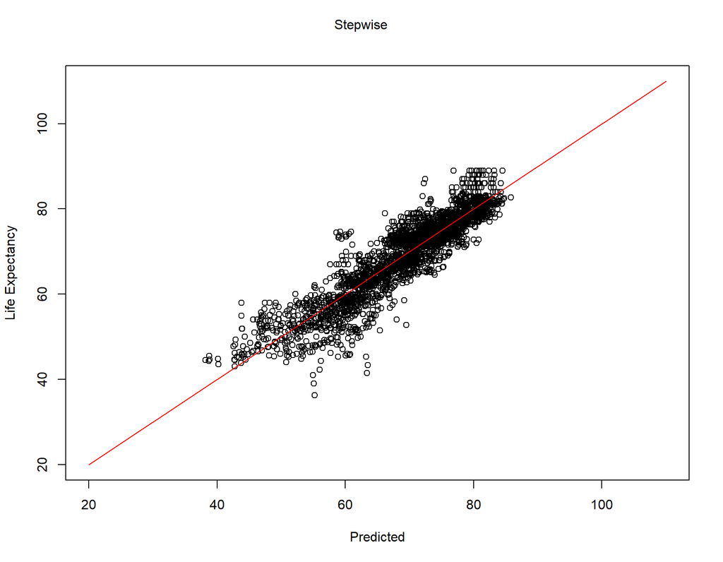

```r
plot(final.predictive$fitted.values,Life$life_expectancy,xlab="Predicted",ylab="Life Expectancy",xlim=c(20,110),ylim=c(20,110) )
lines(c(20,110),c(20,110),col="red")
mtext("Stepwise", side = 3, line = -2, outer = TRUE)
```

```r
# final interpretable model
final.interpretable <- lm(life_expectancy ~ status + adult_mortality + percentage_expenditure + measles + polio + total_expenditure + diphtheria + hiv_aids + thinness_10_19_years + income_composition_of_resources + schooling, data=Life)


summary(final.interpretable)
```

```
##
## Call:
## lm(formula = life_expectancy ~ status + adult_mortality + percentage_expenditure +
##     measles + polio + total_expenditure + diphtheria + hiv_aids +
##     thinness_10_19_years + income_composition_of_resources +
##     schooling, data = Life)
##
## Residuals:
##      Min       1Q   Median       3Q      Max
## -22.2898  -2.0852  -0.0477   2.3129  17.2392
##
## Coefficients:
##                                   Estimate Std. Error t value Pr(>|t|)
## (Intercept)                      5.485e+01  6.388e-01  85.867  < 2e-16 ***
## statusDeveloping                -1.012e+00  2.613e-01  -3.874 0.000109 ***
## adult_mortality                 -2.054e-02  8.131e-04 -25.257  < 2e-16 ***
## percentage_expenditure           3.197e-04  4.463e-05   7.164 9.88e-13 ***
## measles                         -3.447e-05  6.968e-06  -4.947 7.96e-07 ***
## polio                            3.128e-02  4.570e-03   6.845 9.31e-12 ***
## total_expenditure                2.900e-02  3.428e-02   0.846 0.397633
## diphtheria                       4.025e-02  4.545e-03   8.856  < 2e-16 ***
## hiv_aids                        -4.869e-01  1.800e-02 -27.049  < 2e-16 ***
## thinness_10_19_years            -1.433e-01  2.091e-02  -6.851 8.91e-12 ***
## income_composition_of_resources  6.870e+00  6.497e-01  10.574  < 2e-16 ***
## schooling                        7.956e-01  4.319e-02  18.419  < 2e-16 ***
## ---
## Signif. codes:  0 '***' 0.001 '**' 0.01 '*' 0.05 '.' 0.1 ' ' 1
##
## Residual standard error: 4.185 on 2916 degrees of freedom
## Multiple R-squared:  0.8076, Adjusted R-squared:  0.8069
## F-statistic:  1113 on 11 and 2916 DF,  p-value: < 2.2e-16
```

```r
confint(final.interpretable)
```

```
##                                         2.5 %        97.5 %
## (Intercept)                      5.360161e+01  5.610681e+01
## statusDeveloping                -1.524759e+00 -4.999658e-01
## adult_mortality                 -2.213172e-02 -1.894300e-02
## percentage_expenditure           2.322167e-04  4.072333e-04
## measles                         -4.813747e-05 -2.081051e-05
## polio                            2.231698e-02  4.023690e-02
## total_expenditure               -3.821435e-02  9.621340e-02
## diphtheria                       3.133698e-02  4.916035e-02
## hiv_aids                        -5.221528e-01 -4.515681e-01
## thinness_10_19_years            -1.842852e-01 -1.022717e-01
## income_composition_of_resources  5.596393e+00  8.144404e+00
## schooling                        7.109263e-01  8.803179e-01
```

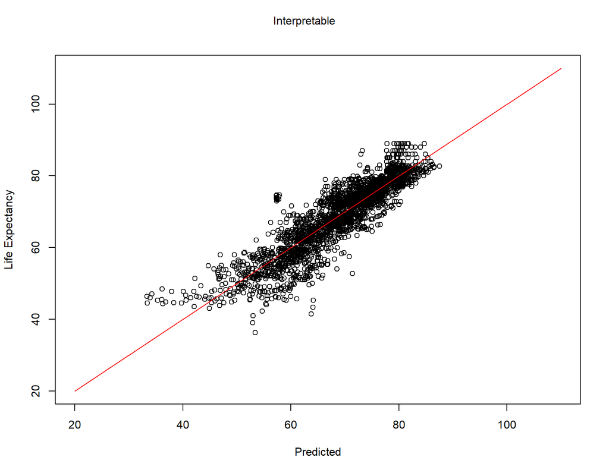

```r
plot(final.interpretable$fitted.values,Life$life_expectancy,xlab="Predicted",ylab="Life Expectancy",xlim=c(20,110),ylim=c(20,110) )
lines(c(20,110),c(20,110),col="red")
mtext("Interpretable", side = 3, line = -2, outer = TRUE)
```

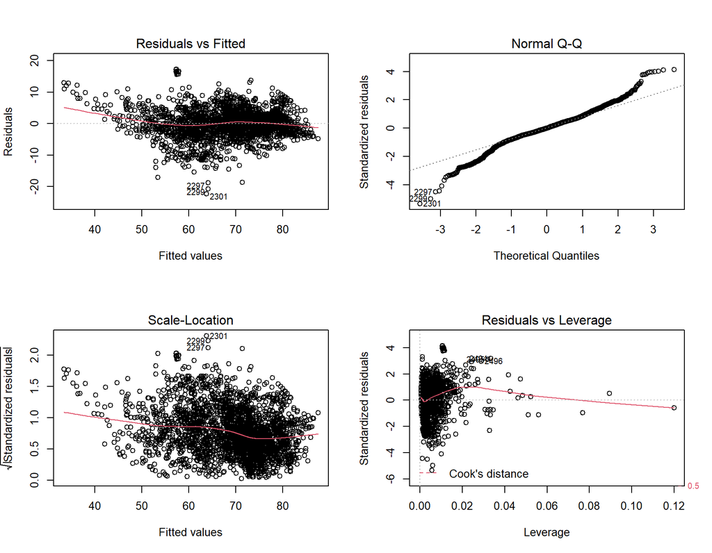

```r
par(mfrow=c(2,2))
plot(final.interpretable)
```

```r
anova(final.predictive, final.interpretable)
```

|  | Res.Df | RSS | Df | Sum of Sq | F | Pr(>F) |
| --- | --- | --- | --- | --- | --- | --- |
| 1 | 2913 | 45082.67 | NA | NA | NA | NA |
| 2 | 2916 | 51073.09 | -3 | -5990.429 | 129.0231 | 1.790762e-78 |

H0: Predictive Model Fit = Interpretable Model Fit  
Ha: Predictive Model Fit != Interpretable Model Fit

There is sufficient evidence to suggest that these models do not fit the data the same.

Reject H0

p-value: < 2.2e-16

## Comparing the models

```r
# Function for Root Mean Squared Error
RMSE <- function(error) { sqrt(mean(error^2)) }
ASE <- function(error) { mean(error^2) }

RMSE(final.modelbwd$residuals)
```

```
## [1] 3.925789
```

```r
RMSE(final.modelstp$residuals)
```

```
## [1] 3.923912
```

```r
RMSE(final.modellso$residuals)
```

```
## [1] 4.1586
```

```r
RMSE(final.interpretable$residuals)
```

```
## [1] 4.176481
```

```r
ASE(final.modelbwd$residuals)
```

```
## [1] 15.41182
```

```r
ASE(final.modelstp$residuals)
```

```
## [1] 15.39709
```

```r
ASE(final.modellso$residuals)
```

```
## [1] 17.29395
```

```r
ASE(final.interpretable$residuals)
```

```
## [1] 17.443
```

```r
summary(final.modelbwd)$adj.r.squared
```

```
## [1] 0.8292704
```

```r
summary(final.predictive)$adj.r.squared
```

```
## [1] 0.8293751
```

```r
summary(final.modellso)$adj.r.squared
```

```
## [1] 0.8086831
```

```r
summary(final.interpretable)$adj.r.squared
```

```
## [1] 0.8069019
```

```r
AIC(final.modelbwd, final.predictive, final.modellso, final.interpretable)
```

|  | df | AIC |
| --- | --- | --- |
| final.modelbwd | 15 | 16347.78 |
| final.predictive | 16 | 16346.98 |
| final.modellso | 11 | 16677.15 |
| final.interpretable | 13 | 16706.28 |

```r
BIC(final.modelbwd, final.modelstp, final.modellso, final.interpretable)
```

|  | df | BIC |
| --- | --- | --- |
| final.modelbwd | 15 | 16437.51 |
| final.modelstp | 16 | 16442.69 |
| final.modellso | 11 | 16742.95 |
| final.interpretable | 13 | 16784.04 |